# 06 Two factor models

# loading DEG object created in “02_Normalize_DGE.Rmd”

```r
load("../output/timecourseDGE.Rdata")
```

check the experimental factors so that we know what we have

```r
dge$samples$day_time <- str_c(dge$samples$sampling_day,"-",dge$samples$sampling_time)

cat("soil_trt: ", unique(dge$samples$soil_trt), "\n\n")
```

```
## soil_trt:  SBC_OLD ATM_BLANK
```

```r
cat("genotype: ", unique(dge$samples$genotype), "\n\n")
```

```
## genotype:  FPsc
```

```r
cat("day_time: ", unique(dge$samples$day_time), "\n\n")
```

[output not shown]

Create a tibble to hold data and models. Each row of the tibble will correspond to one time point. Each row has a subsetted dge that corresponds to that time point.

```r
models <- tibble(day_time=unique(dge$samples$day_time))
models <- models %>%
  separate(day_time, into=c("day", "time"), sep="-", remove=FALSE) %>%
  mutate(dge=map(day_time, ~ dge[,dge$samples$day_time==.]))

#Do NOT print the full models tibble to the screen, it slows everything way down!!
#models

models %>% dplyr::select(-dge) #%>% View()
```

```
## # A tibble: 24 x 3
##    day_time          day   time
##    <chr>             <chr> <chr>
##  1 04-2_afternoon    04    2_afternoon
##  2 04-5_night_2      04    5_night_2
##  3 10-2_afternoon    10    2_afternoon
##  4 03-5_night_2      03    5_night_2
##  5 13-1_morn         13    1_morn
##  6 03-1_morn         03    1_morn
##  7 08-2_afternoon    08    2_afternoon
##  8 14-1_morn         14    1_morn
##  9 04-3_evening_5.30 04    3_evening_5.30
## 10 13-4_night_1      13    4_night_1
## # … with 14 more rows
```

# MDS plot bcv (under construction)

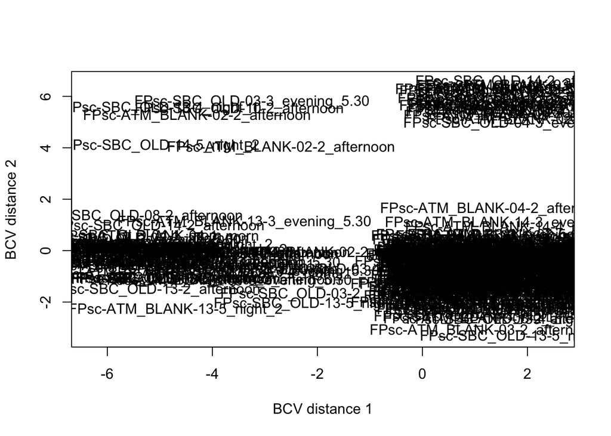

```r
# MDS plot
mds <- plotMDS(dge,method = "bcv",labels=dge$samples$group,gene.selection = "pairwise",dim.plot = c(1,2),ndim=5)
```

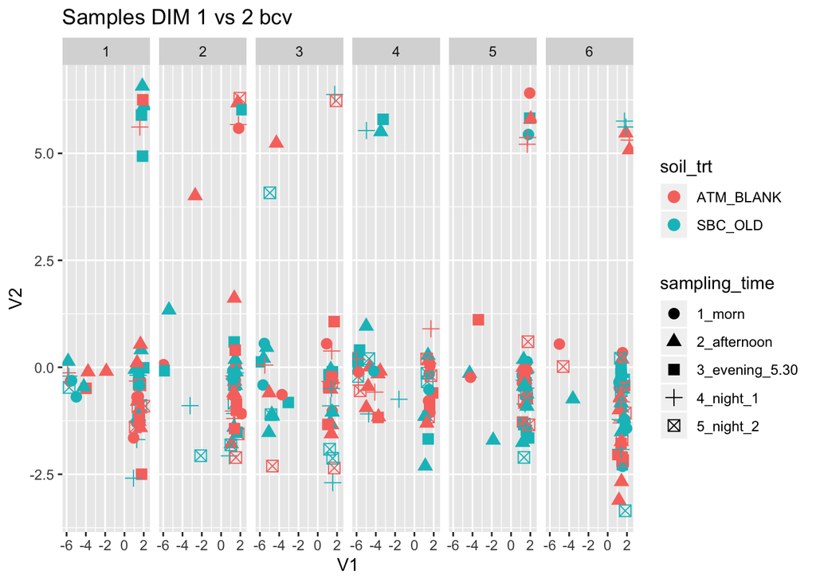

```r
# sample tibble
samples.tibble<-dge$samples %>% as_tibble() %>% bind_cols(data.frame(sample=row.names(dge$samples)),.)
# MDS plot data
mds.pl <- as_tibble(mds$cmdscale.out) %>%
  bind_cols(data.frame(sample=row.names(mds$cmdscale.out)),.) %>%
  inner_join(samples.tibble,by="sample")
# ggplot2 version
p.bcv<-mds.pl %>% ggplot(aes(x=V1,y=V2, shape=sampling_time, color=soil_trt,label=sampling_day)) + geom_point(size=3) + ggtitle("timecourse Samples DIM 1 vs 2 bcv")+ facet_grid(sampling_time~sampling_day) + theme_gray()
ggsave(p.bcv,filename="../output/timecourse.mds.bcv.1and2.png",width=12,height=8)

mds.pl %>% ggplot(aes(x=V1,y=V2, shape=sampling_time, color=soil_trt,label=sampling_day)) + geom_point(size=3) + ggtitle("Samples DIM 1 vs 2 bcv")+ facet_grid(.~block)
```

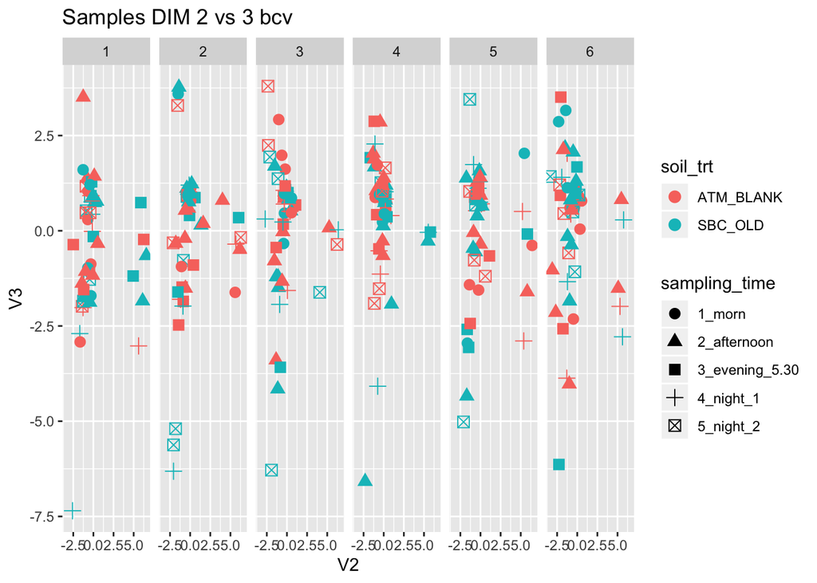

```r
mds.pl %>% ggplot(aes(x=V2,y=V3, shape=sampling_time, color=soil_trt,label=sampling_day)) + geom_point(size=3) + ggtitle("Samples DIM 2 vs 3 bcv")+ facet_grid(.~block)
```

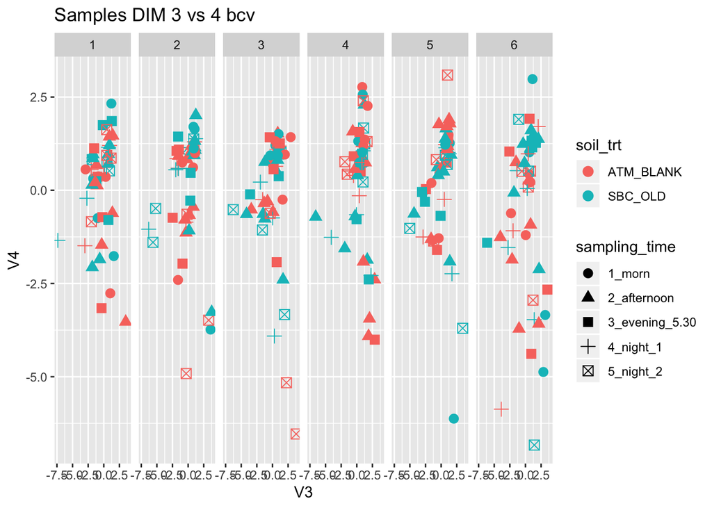

```r
mds.pl %>% ggplot(aes(x=V3,y=V4, shape=sampling_time, color=soil_trt,label=sampling_day)) + geom_point(size=3) + ggtitle("Samples DIM 3 vs 4 bcv")+ facet_grid(.~block)
```

```r
# no large block effects
```

# MDS plot logFC (under construction)

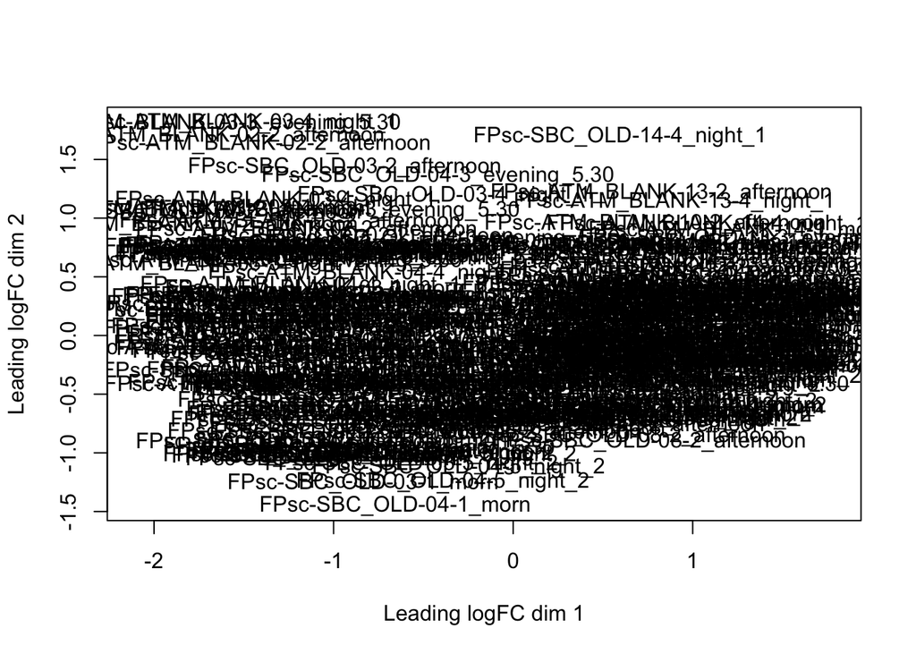

```r
# MDS plot
mds.logFC <- plotMDS(dge,method = "logFC",labels=dge$samples$group,gene.selection = "pairwise",dim.plot = c(1,2),ndim=5)
```

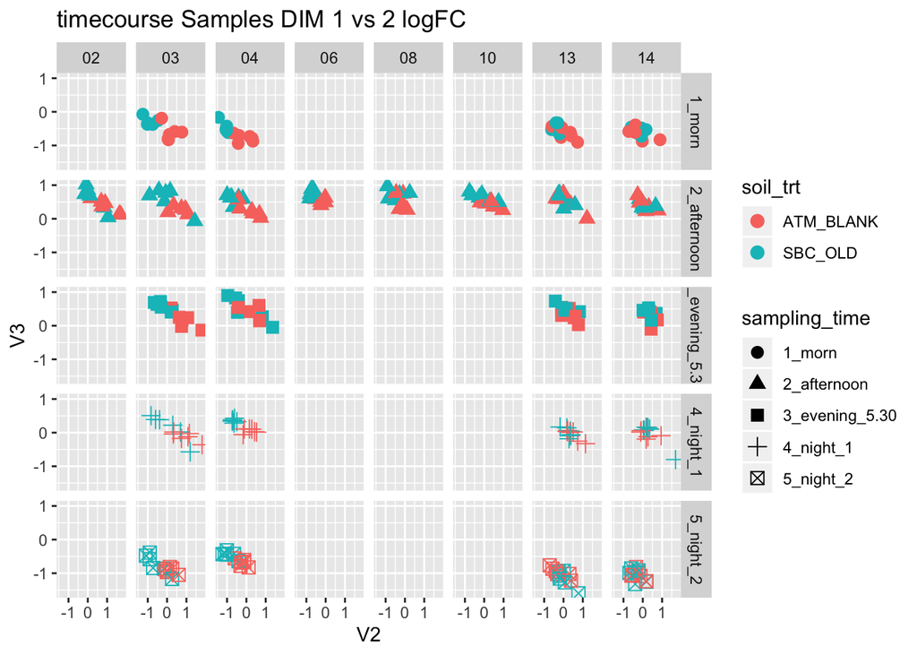

```r
# sample tibble
samples.tibble<-dge$samples %>% as_tibble() %>% bind_cols(data.frame(sample=row.names(dge$samples)),.)
# MDS plot data
mds.logFC.pl <- as_tibble(mds.logFC$cmdscale.out) %>%
  bind_cols(data.frame(sample=row.names(mds$cmdscale.out)),.) %>%
  inner_join(samples.tibble,by="sample")
# ggplot2 version
p.logFC<-mds.logFC.pl %>% ggplot(aes(x=V1,y=V2, shape=sampling_time, color=soil_trt,label=sampling_day)) + geom_point(size=3) + ggtitle("timecourse Samples DIM 1 vs 2 logFC")+ facet_grid(sampling_time~sampling_day) + theme_gray()
ggsave(p.logFC,filename="../output/timecourse.mds.logFC.1and2.png",width=12,height=8)
# V2, V2
mds.logFC.pl %>% ggplot(aes(x=V2,y=V3, shape=sampling_time, color=soil_trt,label=sampling_day)) + geom_point(size=3) + ggtitle("timecourse Samples DIM 1 vs 2 logFC")+ facet_grid(sampling_time~sampling_day) + theme_gray()
```

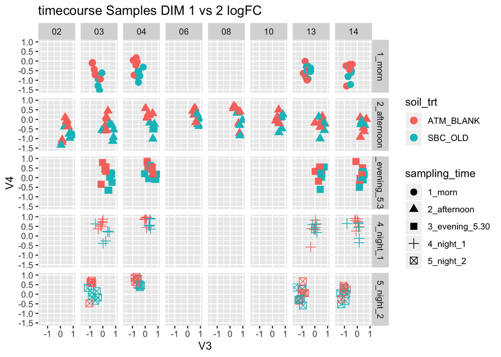

```r
ggsave(filename="../output/timecourse.mds.logFC.2and3.png",width=12,height=8)

# V3, V4
mds.logFC.pl %>% ggplot(aes(x=V3,y=V4, shape=sampling_time, color=soil_trt,label=sampling_day)) + geom_point(size=3) + ggtitle("timecourse Samples DIM 1 vs 2 logFC")+ facet_grid(sampling_time~sampling_day) + theme_gray()
```

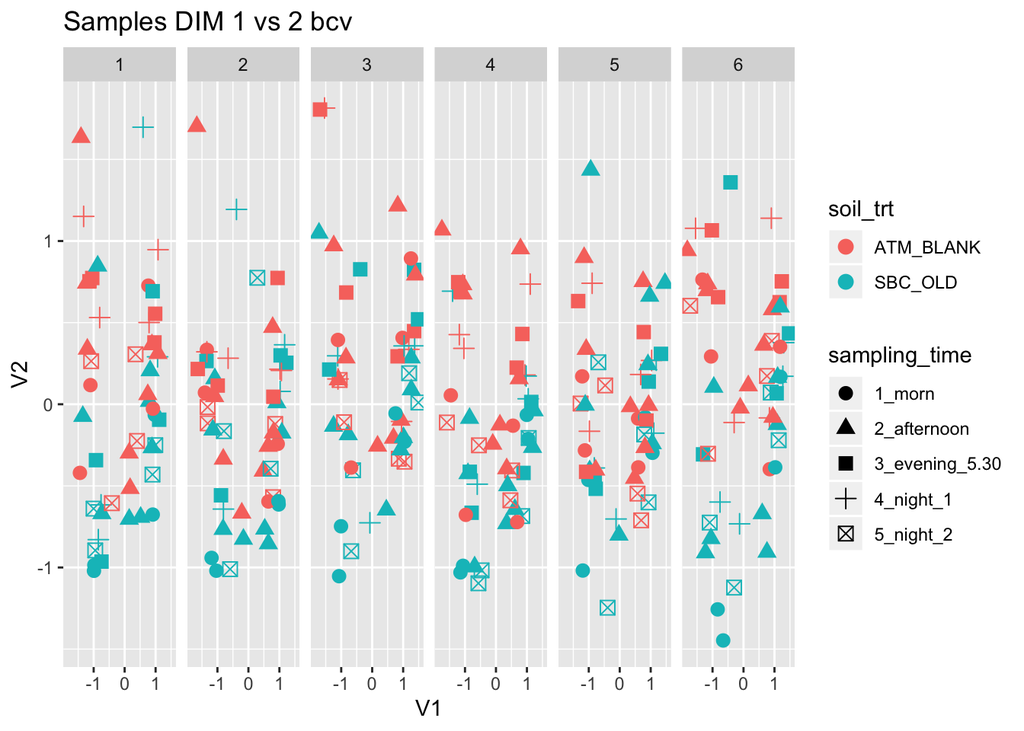

```r
ggsave(filename="../output/timecourse.mds.logFC.3and4.png",width=12,height=8)


mds.logFC.pl %>% ggplot(aes(x=V1,y=V2, shape=sampling_time, color=soil_trt,label=sampling_day)) + geom_point(size=3) + ggtitle("Samples DIM 1 vs 2 bcv")+ facet_grid(.~block)
```

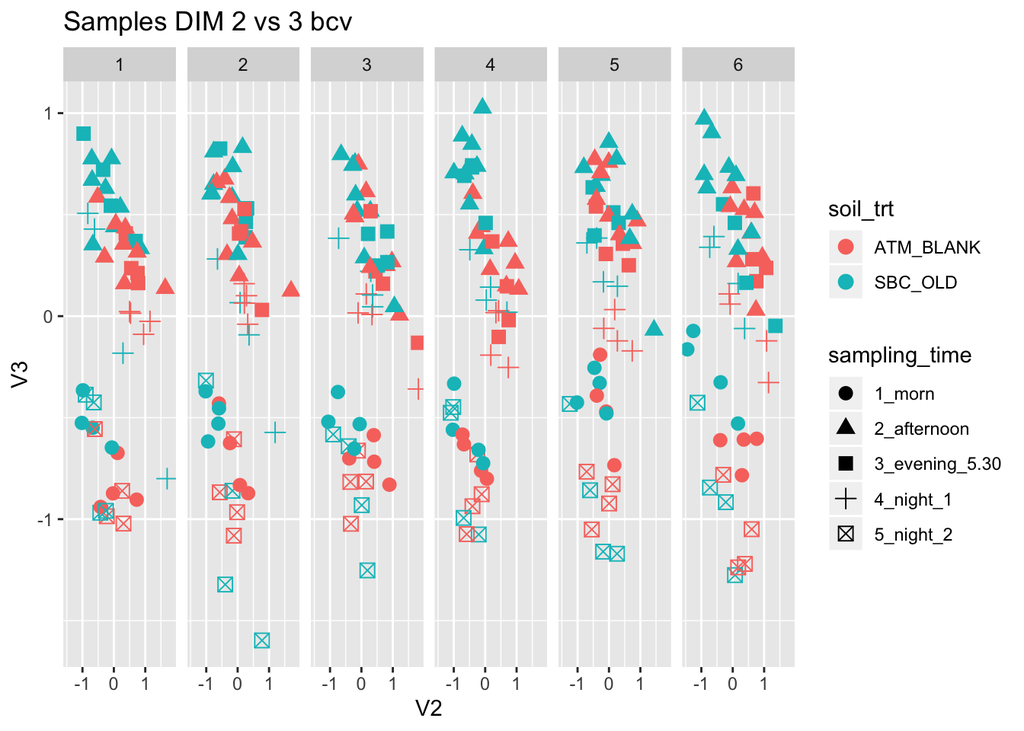

```r
mds.logFC.pl %>% ggplot(aes(x=V2,y=V3, shape=sampling_time, color=soil_trt,label=sampling_day)) + geom_point(size=3) + ggtitle("Samples DIM 2 vs 3 bcv")+ facet_grid(.~block)
```

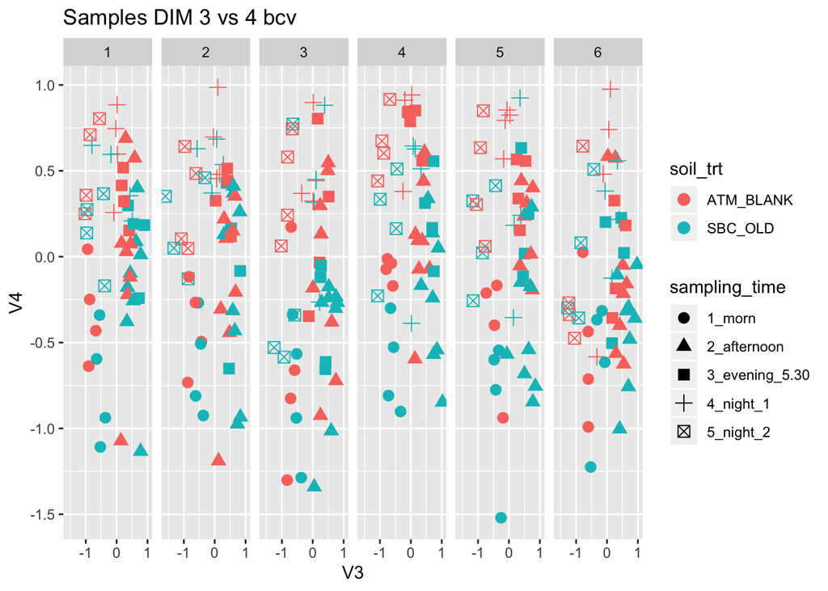

```r
mds.logFC.pl %>% ggplot(aes(x=V3,y=V4, shape=sampling_time, color=soil_trt,label=sampling_day)) + geom_point(size=3) + ggtitle("Samples DIM 3 vs 4 bcv")+ facet_grid(.~block)
```

```r
# no large block effects
```

# “2-afternoon” data. y ~ trt + day + trt:day

```r
# subset data
dge.twoafternoon<-dge[,dge$samples$sampling_time=="2_afternoon"]
# reset normalization factor
dge.twoafternoon$samples$norm.factors<-1 # # No matter which case, non-normalize libraries.
# filtering
dge.twoafternoon<-dge.twoafternoon[rowSums(cpm(dge.twoafternoon)>1) >=3,keep.lib.sizes=FALSE]
# #relevel soil_trt to "SBC_OLD"
dge.twoafternoon$samples<-dge.twoafternoon$samples %>% mutate(soil_trt=fct_relevel(soil_trt,"ATM_BLANK")) # %>% str()
## model
dge.twoafternoon.design <- with(dge.twoafternoon$samples, model.matrix(~ soil_trt + sampling_day + soil_trt:sampling_day + block))
# estimateDisp
dge.twoafternoon <- estimateDisp(dge.twoafternoon,design = dge.twoafternoon.design)
## fit linear model
dge.twoafternoon.fit<- glmFit(dge.twoafternoon,dge.twoafternoon.design)
```

## get DEGs, soil_trt effects (coef=c(“SBC_OLD”))

```r
twoafternoon.trtlive.lrt <- glmLRT(dge.twoafternoon.fit,coef = c("soil_trtSBC_OLD"))
## all
twoafternoon.trtlive.DEGs.all <- topTags(twoafternoon.trtlive.lrt,n = Inf,p.value = 1)$table
## pvalue < 0.05
twoafternoon.trtlive.DEGs.all %>% filter(FDR<0.05) %>% summarize(n()) # 1474
```

```
##    n()
## 1 1474
```

## get DEGs, soil_trt interactions

```r
twoafternoon.interaction.trtlive.samplingday.lrt <- glmLRT(dge.twoafternoon.fit,coef = str_which(colnames(dge.twoafternoon.design),"soil_trtSBC_OLD:"))
## all
twoafternoon.interaction.trtlive.samplingday.lrt.DEGs.all <- topTags(twoafternoon.interaction.trtlive.samplingday.lrt,n = Inf,p.value = 1)$table
## pvalue < 0.05
twoafternoon.interaction.trtlive.samplingday.lrt.DEGs.all %>% filter(FDR<0.05) %>% summarize(n()) # 310
```

```
##   n()
## 1 310
```

## get DEGs, any soil_trt effects combined

```r
twoafternoon.any.trtlive.lrt <- glmLRT(dge.twoafternoon.fit,coef = str_which(colnames(dge.twoafternoon.design),"soil_trtSBC_OLD"))
## all
twoafternoon.any.trtlive.DEGs.all <- topTags(twoafternoon.any.trtlive.lrt,n = Inf,p.value = 1)$table
## pvalue < 0.05
twoafternoon.any.trtlive.DEGs.all %>% filter(FDR<0.05) %>% summarize(n()) # 2249
```

```
##    n()
## 1 2249
```

## get DEGs day effects only (). needs to be renamed (March 4, 2020)

- old: twoafternoon.any.trtlive
- new: twoafternoon.any.samplingday

```r
twoafternoon.any.samplingday.lrt <- glmLRT(dge.twoafternoon.fit,coef = str_which(colnames(dge.twoafternoon.design),"^sampling"))
## all
twoafternoon.any.samplingday.DEGs.all <- topTags(twoafternoon.any.samplingday.lrt,n = Inf,p.value = 1)$table
## pvalue < 0.05
twoafternoon.any.samplingday.DEGs.all %>% filter(FDR<0.05) %>% summarize(n()) # 15376
```

```
##     n()
## 1 15376
```